# Simple drawing using the *turtle* module

- Modules are "files that contain code meant to be used in other programs" (Dawson 2010, p. 52)
- Usually group together "resources" related to each other that perform a specific task
- You can create modules for future reuse or install modules written by others
- https://pypi.python.org/pypi is a repository of packages (i.e. they can contain one or several modules) that you can install on your computers
- **Careful** when installing software from external sources

# The turtle module

Turtle graphics is a popular way of introducing programming (to kids). It based on the Logo programming language. Allows creating simple drawings using a "turtle" which can be commanded.

**Commands to move the turtle**

- `turtle.home()` - moves the turtle to origin (0, 0)
- `turtle.goto(x,y)` - moves the turtle to (x,y)
- `turtle.forward(distance)` and `turtle.fd(distance)` - moves the turtle forward by the specified distance
- `turtle.backward(distance)` and `turtle.bk(distance)` - moves the turtle backwards by the specified distance
- `turtle.right(angle)` - rotates the turtle right by angle units
- `turtle.left(angle)` - rotates the turtle left by angle units
- `turtle.circle(radius)` - draws a circle of a given radius

# The turtle module

**Pen control**

- `turtle.up()` - puts the pen up
- `turtle.down()` - puts the pen down
- `turtle.pensize(size)` - sets the thickness of the pen
- `turtle.color(color)` - the name of the color to be used

**More drawing control**

- `turtle.reset()` - deletes the drawing and moves the turtle home
- `turtle.clear()` - deletes the drawing, but does not move the turtle
- `turtle.bye()` - closes the drawing

Read more about the module: https://docs.python.org/3.7/library/turtle.html

# Example of using turtle

How to draw a square

```
# first we need to import the turtle module
import turtle
```

At this stage nothing visible happens

# Example of using turtle

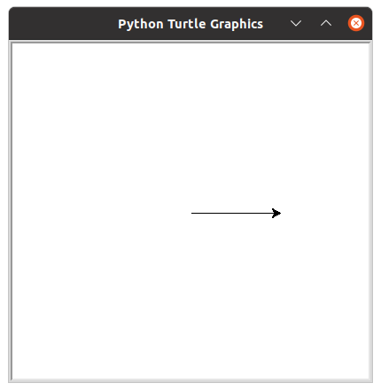

How to draw a square

```
# move the pen forward 100 points
turtle.forward(100)
```

# Example of using turtle

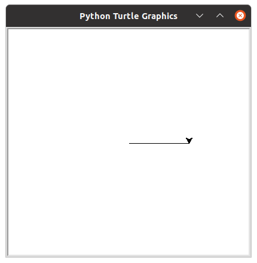

How to draw a square

```
# rotate the pen 90 degrees right
turtle.right(90)
```

# Example of using turtle

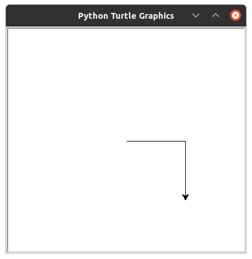

How to draw a square

```
# move another 100 points forward
turtle.forward(100)
```

# Example of using turtle

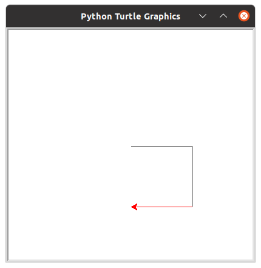

How to draw a square

```
# rotate the turtle by 90 degrees
turtle.right(90)
# change the color to red
turtle.color("red")
turtle.forward(100)
```

# Example using turtle

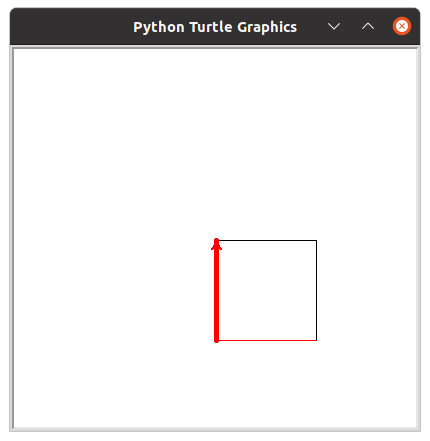

Completing the square

```
# we can change the pen size
turtle.pensize(5)
turtle.right(90)
turtle.forward(100)
```

# Example using turtle

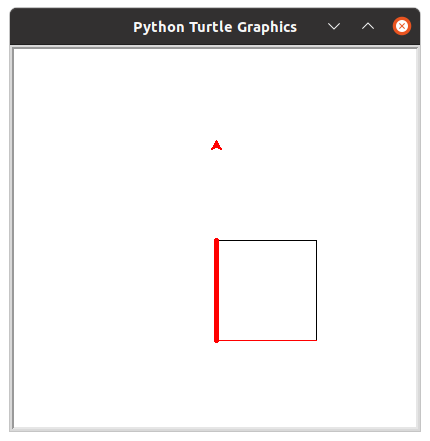

Trying more options in turtle

```
# we can lift the pen
turtle.up()
turtle.forward(100)
```

# Example using turtle

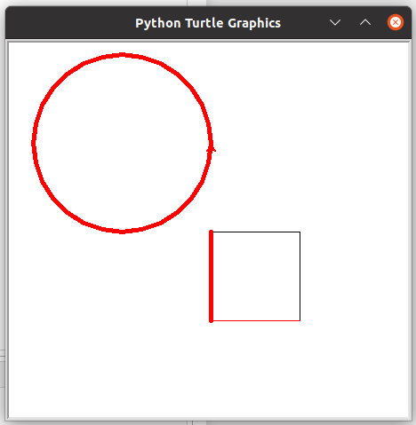

Drawing other shapes

```
# we first need to put the pen down
turtle.down()
# we can draw other shapes like circles
turtle.circle(100)
```

# Further reading

- Example how to use the turtle module: https://opentechschool.github.io/python-beginners/en/simple_drawing.html
- Another nice turtle tutorial: https://dbader.org/blog/python-intro-statements-variables-and-loops (but contains more advanced features, so it may make sense to read this page in a couple of weeks time)

Python programming for linguists by [Constantin Orasan](https://dinel.org.uk) is licensed under a [Creative Commons Attribution-ShareAlike 4.0 International License](http://creativecommons.org/licenses/by-sa/4.0/).  
Find more at https://github.com/dinel/PythonForLinguists.

Python programming for linguists, Week 1 The turtle module